# ciber

lanlab

3/20/2024

## Package downloading and installing

This is a help document for package `ciber`. To use ciber, several packages should be downloaded in advance. Our package can be downloaded from http://github.com/Lan-lab/CIBER. `ciber` package can be installed through source code file **ciber.tar.gz**.

Note: package`Matrix`in this help document is Version 1.3-4 package`bnlearn`in this help document is Version 4.7 package`Seurat`in this help document is Version 3.1.5 package`space`in this help document is Version 0.1-1.1

```r
library(Seurat) # If processing single cell data, Seurat is necessary.
library(foreach)
library(dplyr) # These two packages is useful for parallel processing and speeding up
library(bnlearn) # Core package
library(Matrix) # Core package
library(space) # Core package

# install.packages("ciber.tar.gz", repos = NULL, type = "source")
library(ciber)
```

## learn graph structure from microarray data

### get data

Get test data: HMMA HMMA is a microarray data of HSC differentiation which has 11 different cell types with 21678 genes.

11 cell types can be divided into 2 lineages: myeloid and lymphoid. Including: early differentiation——HSC, MPPa, MPPb myeloid cell types——sCMP, MEP, GMP, MkP, pCFU-E lymphoid cell types——CLP, BLP, DN1

```r
data("HMMA")
head(HMMA)
```

```
##                    HSC  MPPa     MPPb     sCMP   MEP      GMP      MkP   pCFU-E
## 0610005C13Rik 4.400000 4.420 4.170000 4.180000 4.250 4.370000 4.890000 4.320000
## 0610006L08Rik 3.810000 3.950 4.030000 3.960000 4.390 4.460000 4.850000 4.540000
## 0610007C21Rik 8.950000 6.340 7.650000 6.550000 8.040 8.630000 7.030000 7.390000
## 0610007L01Rik 7.693333 8.320 8.423333 8.446667 9.300 9.876667 7.453333 8.023333
## 0610007P08Rik 5.430000 5.742 6.088000 5.870000 6.166 5.790000 5.496000 5.682000
## 0610007P14Rik 7.930000 7.700 7.760000 7.160000 8.820 8.820000 7.530000 7.540000
##                CLP      BLP  DN1
## 0610005C13Rik 4.15 4.510000 4.19
## 0610006L08Rik 4.38 4.330000 4.28
## 0610007C21Rik 9.03 8.740000 8.68
## 0610007L01Rik 8.35 8.213333 7.69
## 0610007P08Rik 5.89 5.896000 5.63
## 0610007P14Rik 8.47 8.280000 7.85
```

```r
ctypes <- colnames(HMMA)
ctypes
```

```
##  [1] "HSC"    "MPPa"   "MPPb"   "sCMP"   "MEP"    "GMP"    "MkP"    "pCFU-E"
##  [9] "CLP"    "BLP"    "DN1"
```

### learn structure set

By `BNLearning` function, ciber can learn directed graph structure from microarray data. We can give a set of parameters in and `BNLearning` will give back a list of network structures back. Besides, different methods for calculating indirect graph and different methods for calculation directions can be chosen. **cmi2ni** is the most frequently used indirect graph calculating method while **hc** is the most frequently used direction calculation method.

```r
test <- HMMA[names(HMMA_glist)[1:3000],]
net_struc_ori <- BNLearning(test,params=seq(from=0.08,to=0.23,length.out=10),
                            root='HSC',mode='bulk',ncores=5)
net_struc_ori[[1]] # net_struc_ori is a list of graphs of different parameters
```

```
##
##   Bayesian network learned via Score-based methods
##
##   model:
##    [HSC][MPPa|HSC][MPPb|HSC:MPPa][CLP|MPPa:MPPb][DN1|HSC:CLP]
##    [sCMP|HSC:MPPa:MPPb:CLP:DN1][GMP|MPPa:sCMP:CLP][MEP|GMP]
##    [BLP|MPPb:sCMP:GMP:CLP:DN1][pCFU-E|sCMP:MEP]
##    [MkP|MPPa:MPPb:sCMP:MEP:GMP:pCFU-E]
##   nodes:                                 11
##   arcs:                                  29
##     undirected arcs:                     0
##     directed arcs:                       29
##   average markov blanket size:           7.27
##   average neighbourhood size:            5.27
##   average branching factor:              2.64
##
##   learning algorithm:                    Hill-Climbing
##   score:                                 BIC (Gauss.)
##   penalization coefficient:              4.003184
##   tests used in the learning procedure:  246
##   optimized:                             TRUE
```

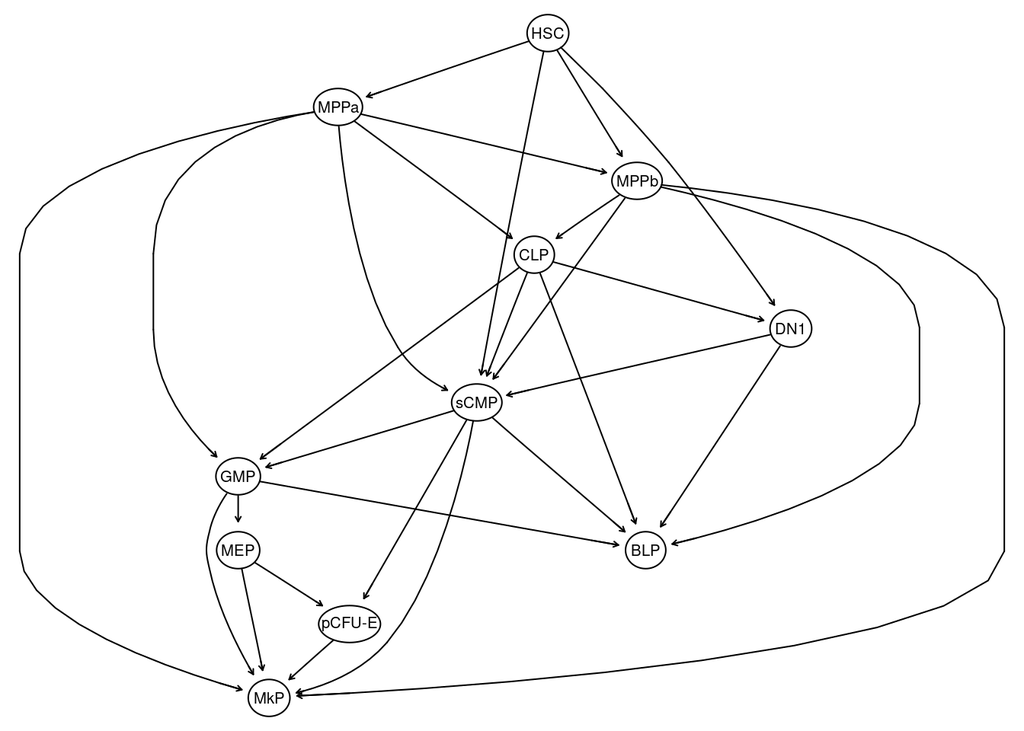

```r
graphviz.plot(net_struc_ori[[1]],shape='ellipse') # View the first graph
```

### combine structure set to get a reasonable network structure

After `BNLearning`, we get a list of graph structures waiting to be combined. We can use the function `combineDAGs` for the combination of graph structures. Then, function `df2mat` can be used to give a glimpse; function `rmCyc` can be used for circle removement.

The Emin is usually 1-2 times of node number. while Emax is usually 2-3 times of node number.

```r
library(tidyr)
net_struc <- combineDAGs(net_struc_ori,Emin=20,Emax=30)
df2mat(net_struc) # take a glimpse
```

```
##        BLP CLP DN1 GMP HSC MEP MkP MPPa MPPb pCFU-E sCMP
## BLP      0   0   1   1   0   0   0    0    1      0    1
## CLP      3   0   2   3   0   0   1    0    1      0    1
## DN1      2   0   0   0   0   0   0    0    0      0    1
## GMP      2   0   0   0   0   2   1    0    0      0    1
## HSC      0   1   1   0   0   0   1    3    2      0    3
## MEP      0   0   0   0   0   0   2    0    0      3    0
## MkP      0   0   0   0   0   0   0    1    0      1    0
## MPPa     0   3   0   2   0   0   2    0    3      0    3
## MPPb     1   2   0   0   0   0   1    0    0      0    3
## pCFU-E   0   0   0   1   0   0   2    0    0      0    0
## sCMP     1   0   2   2   0   0   1    0    0      1    0
```

```r
df2mat(rmCyc(net_struc)) # remove the circle
```

```
##        BLP CLP GMP HSC MEP MPPa MPPb pCFU-E sCMP DN1 MkP
## BLP      0   0   1   0   0    0    1      0    1   1   0
## CLP      0   0   3   0   0    0    0      0    1   2   1
## GMP      0   0   0   0   2    0    0      0    0   0   1
## HSC      0   1   0   0   0    3    2      0    3   1   1
## MEP      0   0   0   0   0    0    0      3    0   0   2
## MPPa     0   3   2   0   0    0    3      0    3   0   2
## MPPb     0   2   0   0   0    0    0      0    3   0   1
## pCFU-E   0   0   0   0   0    0    0      0    0   0   2
## sCMP     0   0   2   0   0    0    0      1    0   2   1
## DN1      0   0   0   0   0    0    0      0    0   0   0
## MkP      0   0   0   0   0    0    0      0    0   0   0
```

```r
net_struc <- rmCyc(net_struc)
```

### modify structure according to bnlearn result

Then, we can use function `trimDAG` for the adjustment of network structure. By adding HMMA and primary structure into function, trimDAG return the modified structure according to the given parameters: min_arc; max_arc; threshold_value.

Usually, min_arc is 1 or 2, max_arc is 3 or 4, threshold_value is from 0.8 to 1. Sometimes, trimDAG need to be used for more than one round on different gene sets to get the desired structure.

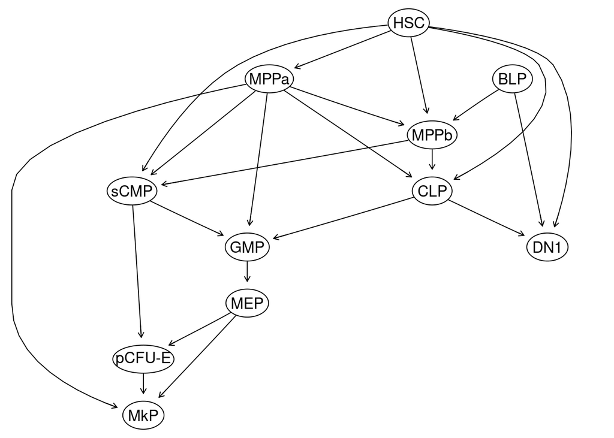

```r
e <-  empty.graph(ctypes)
strc1 <- (net_struc)[,1:2]
strc1[,1]=as.character(strc1[,1])
strc1[,2]=as.character(strc1[,2])
arcs(e) <-  strc1
e <- trimDAG(HMMA,e,2,3,1)
```

```r
e
```

```
##
##   Random/Generated Bayesian network
##
##   model:
##    [HSC][BLP][MPPa|HSC][MPPb|HSC:MPPa:BLP][sCMP|HSC:MPPa:MPPb]
##    [CLP|HSC:MPPa:MPPb][GMP|MPPa:sCMP:CLP][DN1|HSC:CLP:BLP][MEP|GMP]
##    [pCFU-E|sCMP:MEP][MkP|MPPa:MEP:pCFU-E]
##   nodes:                                 11
##   arcs:                                  22
##     undirected arcs:                     0
##     directed arcs:                       22
##   average markov blanket size:           5.27
##   average neighbourhood size:            4.00
##   average branching factor:              2.00
##
##   generation algorithm:                  Empty
```

Add different color.

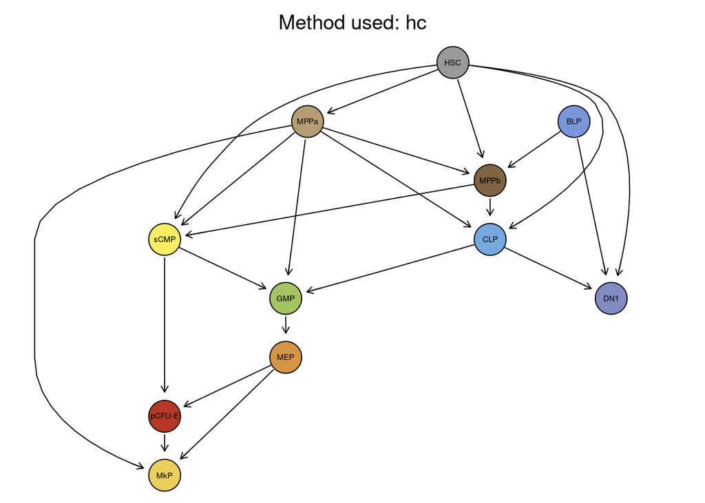

```r
library(igraph)
library(graph)
library(Rgraphviz)
draw_para <- list(fill=c("HSC"='#9A9A99',
                         "MPPa"='#B69D75',
                         "MPPb"='#806342',
                         "CLP"='#76A9E0',
                         "GMP"='#A4C362',
                         "MEP"='#D59546',
                         "pCFU-E"='#B63728',
                         "MkP"='#EACF5C',
                         "DN1"='#838BC3',
                         "sCMP"='#F6ED64',
                         "BLP"='#7A97DC'))
tmp=graphviz.plot(e,shape = 'circle',main=paste0('Method used: ','hc'),render = F)
nodeRenderInfo(tmp) <- draw_para
renderGraph(tmp)
```

## get diffBN from microarray data

After getting a desired network structure, we can use functions below to calculate the diffBN result. 1. `EffectMatrix`: use this function to get the diffBN result of every gene

```r
diffBN <- EffectMatrix(net_struc = e,data = HMMA[1:10,],mode = 'bulk',ncores = 5) # ger diffBN summary
head(diffBN[,1:6])
```

```
##                  HSC~MPPa     HSC~MPPb    HSC~sCMP     HSC~CLP      HSC~DN1
## 0610005C13Rik  0.02205443 -0.074501924 -0.01445879 -0.17089216  0.006907495
## 0610006L08Rik  0.02807658 -0.049305571  0.03153240 -0.09849946  0.009215166
## 0610007C21Rik -0.21552663  0.544555573  0.03495329 -0.31579084 -0.291685883
## 0610007L01Rik  0.03441625 -0.007501692 -0.02220333 -0.06792713 -0.071840130
## 0610007P08Rik -0.01007542 -0.122052041  0.06100698 -0.13397965 -0.009921305
## 0610007P14Rik  0.00346396  0.151784500 -0.17857802  0.26991291  0.067568495
##                  MPPa~MPPb
## 0610005C13Rik  0.006569878
## 0610006L08Rik -0.009458957
## 0610007C21Rik -0.489135770
## 0610007L01Rik  0.001350366
## 0610007P08Rik  0.008914058
## 0610007P14Rik  0.004285158
```

### try another network-construction method

Besides ‘hc’ in the dagMethod, CIBER support different network-construction method including the hybrid method ‘mmhc’ and non-hybrid method ‘tabu’.

Method tabu:

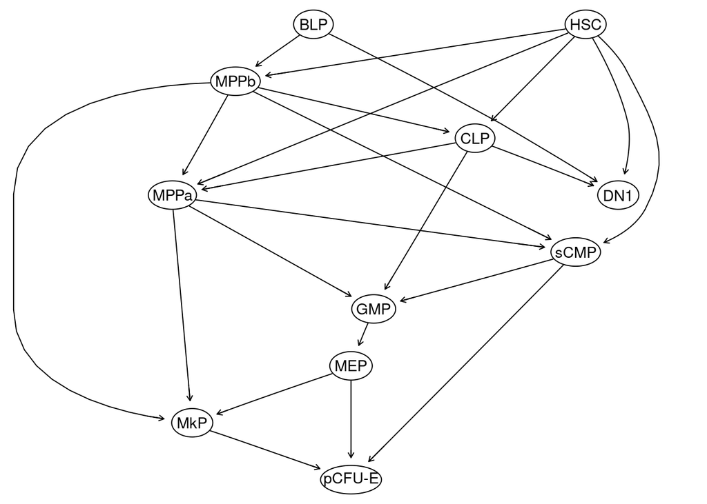

```r
test <- HMMA[names(HMMA_glist)[1:3000],]
net_struc_ori <- BNLearning(test,params=seq(from=0.08,to=0.23,length.out=10),
                            root='HSC',mode='bulk',ncores=5,dagMethod='tabu')
net_struc <- rmCyc(combineDAGs(net_struc_ori,Emin=20,Emax=30))
e <-  empty.graph(ctypes)
strc1 <- (net_struc)[,1:2];strc1[,1]=as.character(strc1[,1]);strc1[,2]=as.character(strc1[,2])
arcs(e) <-  strc1
e <- trimDAG(HMMA,e,2,3,1)
```

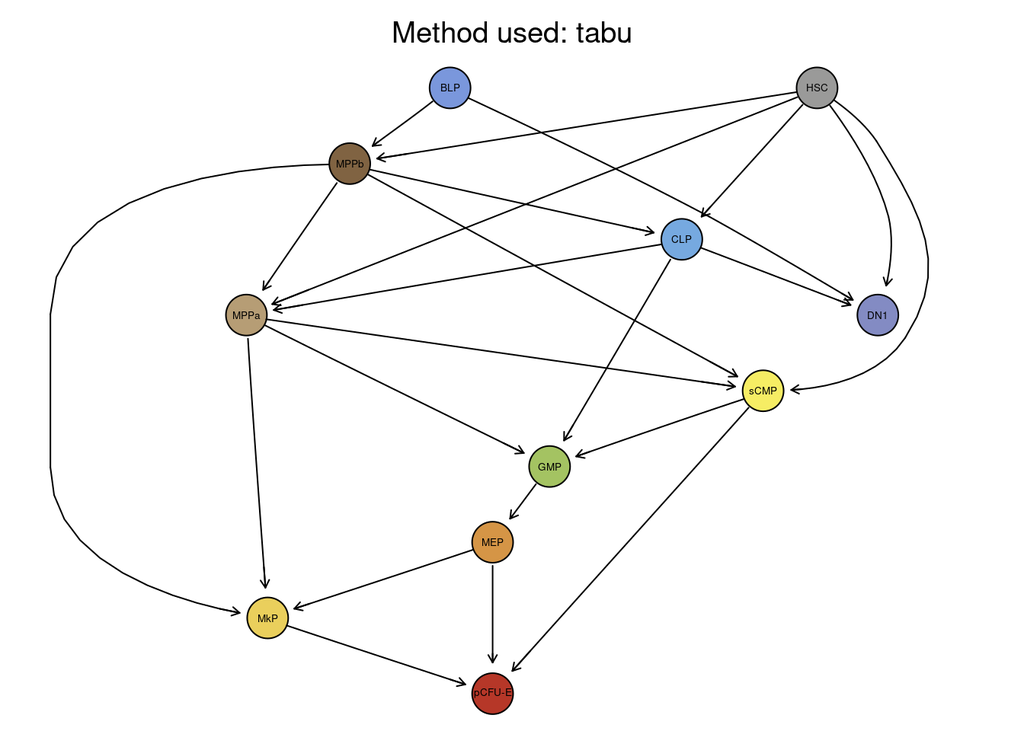

```r
tmp=graphviz.plot(e,shape = 'circle',main=paste0('Method used: ','tabu'),render = F)
nodeRenderInfo(tmp) <- draw_para
renderGraph(tmp)
```

Method mmhc:

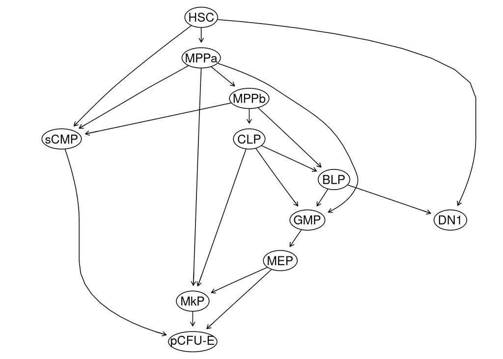

```r
test <- HMMA[names(HMMA_glist)[1:3000],]
net_struc_ori <- BNLearning(test,params=seq(from=0.08,to=0.23,length.out=10),
                            root='HSC',mode='bulk',ncores=5,dagMethod='mmhc')
net_struc <- rmCyc(combineDAGs(net_struc_ori,Emin=20,Emax=30))
e <-  empty.graph(ctypes)
strc1 <- (net_struc)[,1:2];strc1[,1]=as.character(strc1[,1]);strc1[,2]=as.character(strc1[,2])
arcs(e) <-  strc1
e <- trimDAG(HMMA,e,2,3,1)
```

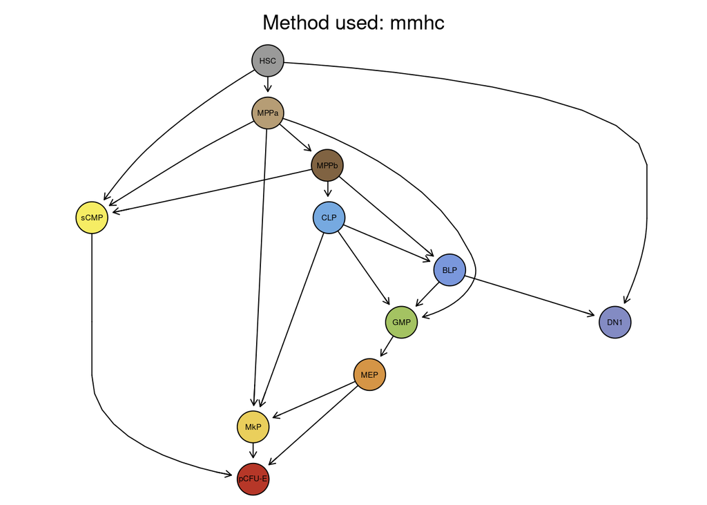

```r
tmp=graphviz.plot(e,shape = 'circle',main=paste0('Method used: ','mmhc'),render = F)
nodeRenderInfo(tmp) <- draw_para
renderGraph(tmp)
```

## learn graph structure from single cell data

### get data

Get test data: HHATAC_TF HHATAC_TF is a single cell atac-seq data of human HSC differentiation.

9 cell types including: “HSC” “MPP” “LMPP” “CMP” “CLP” “MEP” “GMP” “pDC” “mono”

```r
data("HHATAC_TF")
data("HHATAC_TF_glist")
head(HHATAC_TF[,1:10])
```

```
##                                       orig.ident nCount_RNA nFeature_RNA
## singles-BM0828-HSC-fresh-151027-1  SeuratProject -182.18758          782
## singles-BM0828-HSC-fresh-151027-2  SeuratProject  -96.75575          876
## singles-BM0828-HSC-fresh-151027-3  SeuratProject -391.01461          699
## singles-BM0828-HSC-fresh-151027-4  SeuratProject -339.93076          774
## singles-BM0828-HSC-fresh-151027-5  SeuratProject -346.05868          782
## singles-BM0828-HSC-fresh-151027-6  SeuratProject   23.32228          929
## singles-BM0828-HSC-fresh-151027-7  SeuratProject  136.28823          931
## singles-BM0828-HSC-fresh-151027-10 SeuratProject  -22.61046          897
## singles-BM0828-HSC-fresh-151027-11 SeuratProject  -10.83691          891
## singles-BM0828-HSC-fresh-151027-12 SeuratProject -257.08412          777
##                                    celltype
## singles-BM0828-HSC-fresh-151027-1       HSC
## singles-BM0828-HSC-fresh-151027-2       HSC
## singles-BM0828-HSC-fresh-151027-3       HSC
## singles-BM0828-HSC-fresh-151027-4       HSC
## singles-BM0828-HSC-fresh-151027-5       HSC
## singles-BM0828-HSC-fresh-151027-6       HSC
## singles-BM0828-HSC-fresh-151027-7       HSC
## singles-BM0828-HSC-fresh-151027-10      HSC
## singles-BM0828-HSC-fresh-151027-11      HSC
## singles-BM0828-HSC-fresh-151027-12      HSC
```

```r
ctypes <- names(table(HHATAC_TF$celltype))
ctypes
```

```
## [1] "HSC"  "MPP"  "LMPP" "CMP"  "CLP"  "MEP"  "GMP"  "pDC"  "mono"
```

```r
atac_data <- gem2mem(as.data.frame(HHATAC_TF@assays$RNA@data),meta = HHATAC_TF$celltype,FUN = 'mean')
```

### learn structure set

For single cell data, function `BNLearning` is used to get the network structure set just as the function `BNLearning` for microarray data.

Different from BNLearning, BNLearning is the function that considers all the parameters in “params” and cell samplings to get a group of net structures based on ugMethod and dagMethod. BNLearning is suitable for single cell data in SeuratObject format.

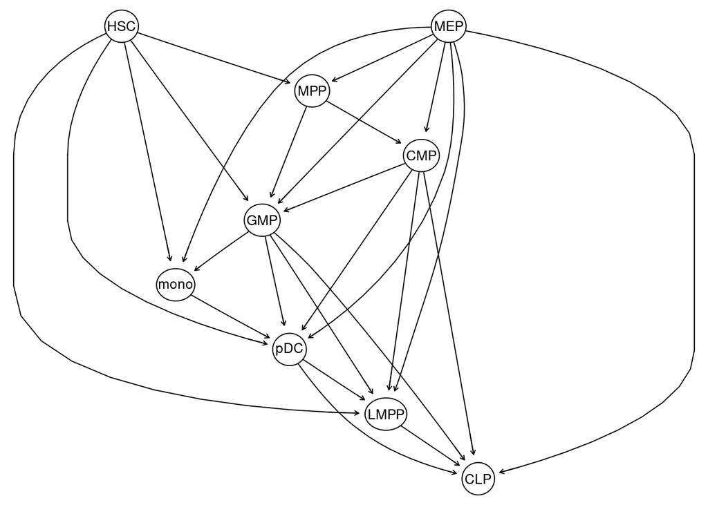

```r
Idents(HHATAC_TF)=HHATAC_TF$celltype
a <- BNLearning(HHATAC_TF, frac = 0.2, N_smpl = 20, params = seq(0.01,0.02,0.001),
                whiteList = NULL, blackList = NULL, root = 'HSC',
                ugMethod = 'space', dagMethod = 'hc', ncores = 20,mode = 'single_cell')
graphviz.plot(a[[1]][[1]],shape='ellipse')
```

### combine structure set to get a reasonable network structure

```r
library(tidyr)
tmp <- lapply(a,function(x){df2mat(combineDAGs(x,Emin = 1,Emax = 50))})
b = norm_mat(tmp[[1]][ctypes,ctypes]);for (i in 2:length(tmp)) {b = b + norm_mat(tmp[[i]][ctypes,ctypes])}
b = rmCycL(mat2df(b))
```

### modify structure according to bnlearn result

Then, we can use function `trimDAG` for the adjustment of network structure. By adding HMMA and primary structure into function, trimDAG return the modified structure according to the given parameters: min_arc; max_arc; threshold_value. Note, for single cell data, we can use `gem2mem` function to transform single cell expression matrix to a cell type expression matrix.

Usually, min_arc is 1 or 2, max_arc is 3 or 4, threshold_value is from 0.8 to 1. Sometimes, trimDAG need to be used for more than one round on different gene sets to get the desired structure. For example, here we use rank 25%-50% variable genes for the first round of trimDAG and use rank 1-25% variable genes for the second.

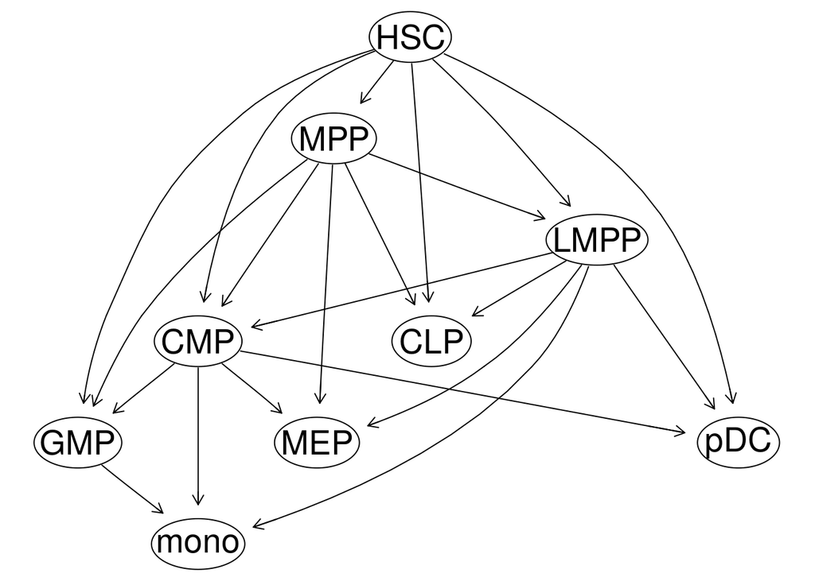

```r
e <-  empty.graph(ctypes)
strc1 <- rmCycL(b)[,1:2]
strc1[,1]=as.character(strc1[,1])
strc1[,2]=as.character(strc1[,2])
arcs(e) <-  strc1
e=arc_modify(atac_data[names(HHATAC_TF_glist)[441:882],],e,2,3,1)
```

```r
e=arc_modify(atac_data[names(HHATAC_TF_glist)[1:442],],e,2,2,1)
```

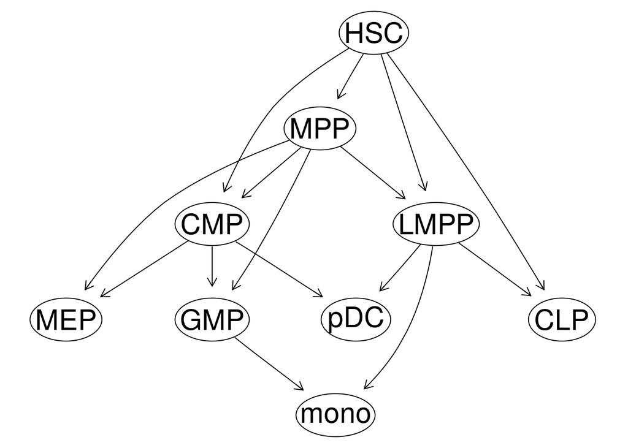

Color the graph:

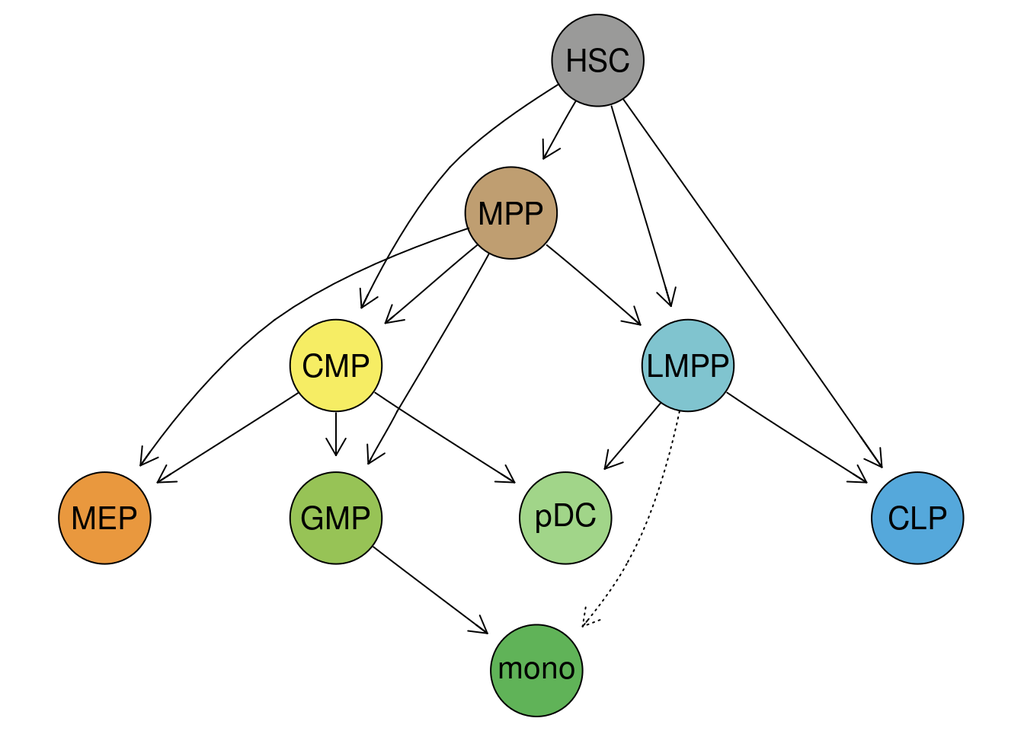

```r
draw_para <- list(fill=c("HSC"='#9A9A99',
                         "MPP"='#BF9E71',
                         "LMPP"='#80C4CF',
                         "CMP"='#F6ED64',
                         "CLP"='#55A8DB',
                         "MEP"='#E9983E',
                         "GMP"='#97C356',
                         "pDC"='#A1D589',
                         "mono"='#60B358'))
ctypes=c('HSC','MPP','LMPP','CMP','CLP','MEP','GMP','pDC','mono')
node_myl=c('sCMP','GMP','MEP','Ery','MkP'); node_lym=c('CLP','BLP','DN1'); node_early=c('HSC','MPP')
correct_arc=c(setEdges('HSC', ctypes, sep = "~"),
              setEdges('MPP', ctypes, sep = "~"),
              setEdges('CMP', ctypes[5:9], sep = "~"),
              setEdges('GMP', 'mono', sep = "~"),
              setEdges('LMPP', c('CLP','pDC','mono','GMP'), sep = "~"))
wrong_arc=setEdges(ctypes, ctypes, sep = "~")[!setEdges(ctypes, ctypes, sep = "~")%in%correct_arc]
correct_or_wrong=c(rep('black',length(correct_arc)),rep('red',length(wrong_arc)));names(correct_or_wrong) = c(correct_arc,wrong_arc)
draw_para2 <- list(col=correct_or_wrong)
kuaxi=c(setEdges('CMP', 'CLP', sep = "~"),
        setEdges('LMPP', c('GMP','mono'), sep = "~"))
not_kua=setEdges(ctypes, ctypes, sep = "~")[!setEdges(ctypes, ctypes, sep = "~")%in%kuaxi]
lty=c(rep('dotted',length(kuaxi)),rep('solid',length(not_kua)));names(lty)=c(kuaxi,not_kua)
draw_para3 <- list(col=correct_or_wrong,lty=lty)
graph_atac_score=graphviz.plot(e,shape = 'circle',main=paste0(''),render = F)
nodeRenderInfo(graph_atac_score) <- draw_para;edgeRenderInfo(graph_atac_score) <- draw_para3; renderGraph(graph_atac_score)
```

## get diffBN from single cell data

After getting a desired network structure, we can use functions below to calculate the diffBN result. 1. `bootstrap_index`: generate several sampling indexes according to metadata; the **bootstrap_times** parameter should be the same with that in function `EffectMatrix` 2. `EffectMatrix`: alculate diffBN results based on a single cell expression data. 3. `calculate_diffBN`: When function `EffectMatrix` is done, the ouput of `EffectMatrix` can be the input of this function to produce diffBN results of other modes

Usually, **bootstrap_times** and **permutation_times** parameter ranges from 20 to 50. For convenience, we use 2 in this help document.

```r
dat_meta=HHATAC_TF$celltype
names(dat_meta)=rownames(HHATAC_TF@meta.data)
index <- bootstrap_index(dat_meta,bootstrap_times=2,ratio=0.2)
test_result <- EffectMatrix(e,HHATAC_TF,dat_meta,index,permutation_time=2,bootstrap_time=2,diffBN_mode='mean',mode='single_cell')
```

```
## [1] "bootstrap_time:1/permutation_time:1"
## [1] "bootstrap_time:1/permutation_time:2"
## [1] "bootstrap_time:2/permutation_time:1"
## [1] "bootstrap_time:2/permutation_time:2"
```

```r
diffBN <- calculate_diffBN(test_result,diffBN_mode='mean')
head(test_result[[1]][[1]])
```

```
##                                         HSC~MPP      HSC~LMPP       HSC~CMP
## ENSG00000008196-LINE2-TFAP2B-D-N1  7.614398e-05 -7.292266e-05  3.977443e-05
## ENSG00000008196-LINE3-TFAP2B-D-N1 -4.249494e-05 -3.032136e-04  2.071387e-04
## ENSG00000008196-LINE4-TFAP2B-D-N1 -6.661102e-05 -2.677988e-04 -8.378814e-05
## ENSG00000008196-LINE5-TFAP2B-D-N1  2.085045e-04  2.197277e-04 -2.458759e-04
## ENSG00000008197-LINE6-TFAP2D-D    -1.081809e-04  5.831626e-04 -1.134180e-04
## ENSG00000087510-LINE7-TFAP2C-D-N3 -2.982317e-05  9.546867e-05  7.108533e-05
##                                         HSC~CLP      MPP~LMPP       MPP~CMP
## ENSG00000008196-LINE2-TFAP2B-D-N1  9.170240e-05 -3.535777e-05 -4.600339e-05
## ENSG00000008196-LINE3-TFAP2B-D-N1 -4.415495e-05  3.955088e-04 -2.884716e-04
## ENSG00000008196-LINE4-TFAP2B-D-N1  2.462078e-04  1.412364e-04  3.063591e-05
## ENSG00000008196-LINE5-TFAP2B-D-N1 -2.473858e-07 -2.992760e-04  2.861764e-04
## ENSG00000008197-LINE6-TFAP2D-D     3.920666e-04 -2.290151e-04  9.761658e-06
## ENSG00000087510-LINE7-TFAP2C-D-N3 -4.874755e-05 -1.647090e-05 -4.659332e-05
##                                         MPP~MEP       MPP~GMP      LMPP~CLP
## ENSG00000008196-LINE2-TFAP2B-D-N1 -1.364375e-05  0.0002268712 -4.620439e-05
## ENSG00000008196-LINE3-TFAP2B-D-N1  4.630636e-05  0.0003502885  2.228375e-05
## ENSG00000008196-LINE4-TFAP2B-D-N1  1.051360e-05 -0.0002742607 -2.726884e-04
## ENSG00000008196-LINE5-TFAP2B-D-N1 -2.819513e-04  0.0002819826 -4.788035e-05
## ENSG00000008197-LINE6-TFAP2D-D    -2.686789e-05 -0.0002043420  3.107730e-04
## ENSG00000087510-LINE7-TFAP2C-D-N3  1.846195e-04 -0.0002098668  8.504545e-05
##                                        LMPP~pDC     LMPP~mono       CMP~MEP
## ENSG00000008196-LINE2-TFAP2B-D-N1 -8.056677e-06 -2.342611e-05 -8.414488e-06
## ENSG00000008196-LINE3-TFAP2B-D-N1  1.252538e-05 -1.242024e-04 -3.781086e-05
## ENSG00000008196-LINE4-TFAP2B-D-N1  1.015836e-04  9.245848e-05  1.144173e-04
## ENSG00000008196-LINE5-TFAP2B-D-N1 -1.103093e-04  1.224550e-04  7.601784e-05
## ENSG00000008197-LINE6-TFAP2D-D    -1.031102e-03  1.126357e-04  1.835155e-04
## ENSG00000087510-LINE7-TFAP2C-D-N3  2.057958e-04 -4.733382e-05  1.461037e-04
##                                         CMP~GMP       CMP~pDC      GMP~mono
## ENSG00000008196-LINE2-TFAP2B-D-N1 -2.505969e-05  0.0001157585 -4.668769e-05
## ENSG00000008196-LINE3-TFAP2B-D-N1 -2.915071e-04  0.0001502921  3.183590e-04
## ENSG00000008196-LINE4-TFAP2B-D-N1  9.659737e-05  0.0000263144  2.575983e-04
## ENSG00000008196-LINE5-TFAP2B-D-N1 -1.361977e-05  0.0001799232  7.572790e-05
## ENSG00000008197-LINE6-TFAP2D-D     5.700126e-05 -0.0006502597 -4.121988e-05
## ENSG00000087510-LINE7-TFAP2C-D-N3 -1.559523e-04  0.0001385007  7.119716e-06
```

```r
table(diffBN[[1]]==test_result[[1]][[1]])
```

```
##
## FALSE  TRUE
## 24696  1764
```

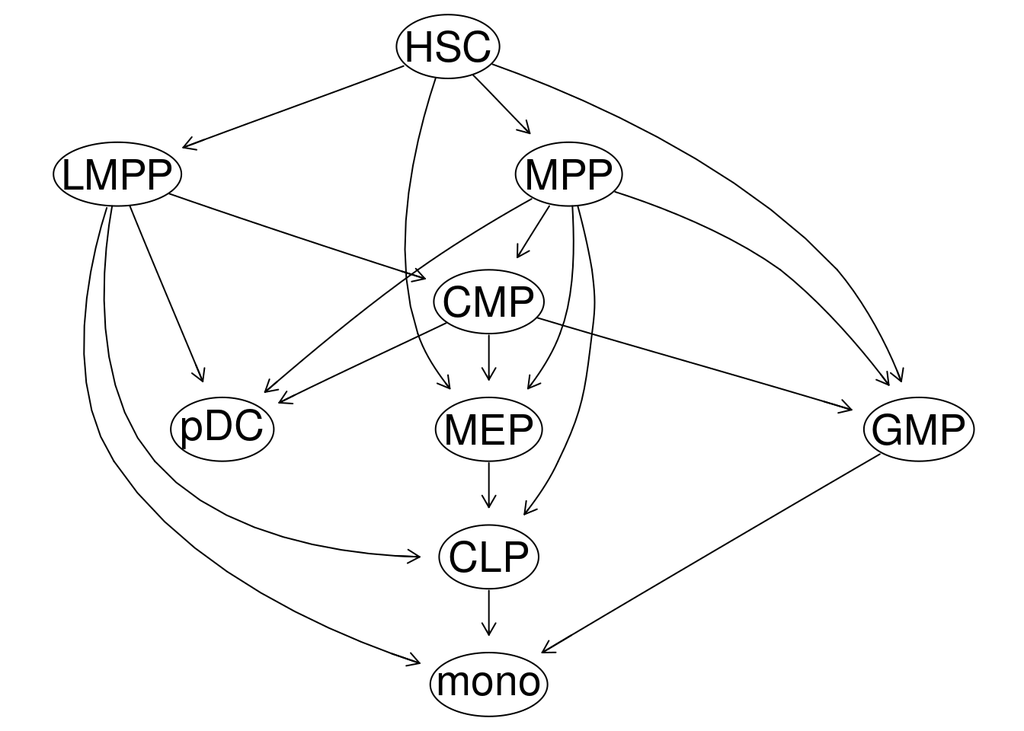

```r
a <- BNLearning(HHATAC_TF, frac = 0.2, N_smpl = 20, params = seq(0.01,0.02,0.001),
                whiteList = NULL, blackList = NULL, root = 'HSC',
                ugMethod = 'space', dagMethod = 'mmhc', ncores = 20,mode = 'single_cell')
tmp <- lapply(a,function(x){df2mat(combineDAGs(x,Emin = 1,Emax = 50))})
b = norm_mat(tmp[[1]][ctypes,ctypes]);for (i in 2:length(tmp)) {b = b + norm_mat(tmp[[i]][ctypes,ctypes])}
b = rmCycL(mat2df(b))
e <-  empty.graph(ctypes)
strc1 <- (b)[,1:2];strc1[,1]=as.character(strc1[,1]);strc1[,2]=as.character(strc1[,2])
arcs(e) <-  strc1
e=arc_modify(atac_data[names(HHATAC_TF_glist)[441:882],],e,2,3,1)
```

```r
e=arc_modify(atac_data[names(HHATAC_TF_glist)[1:442],],e,2,2,1)
```

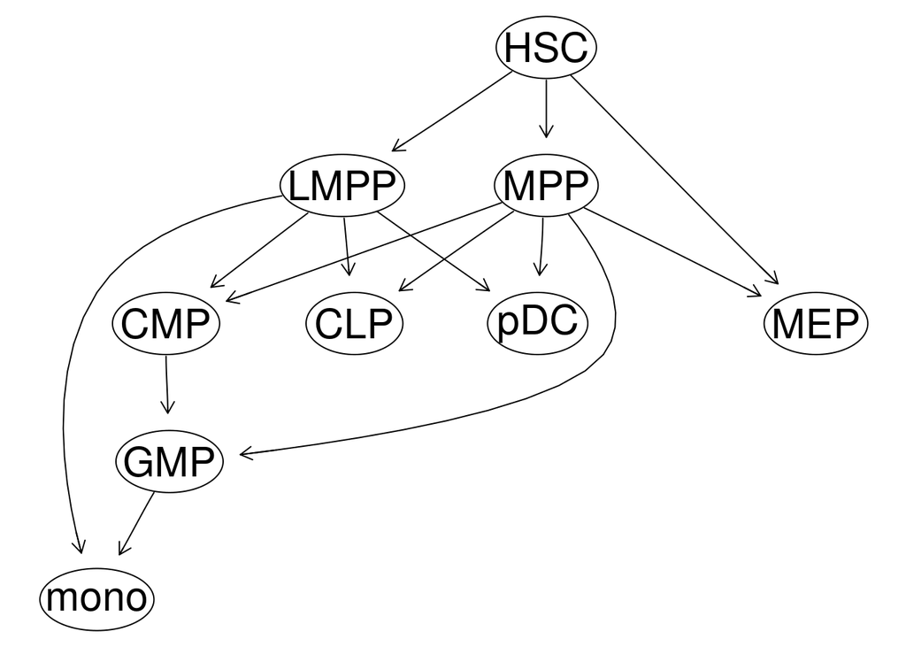

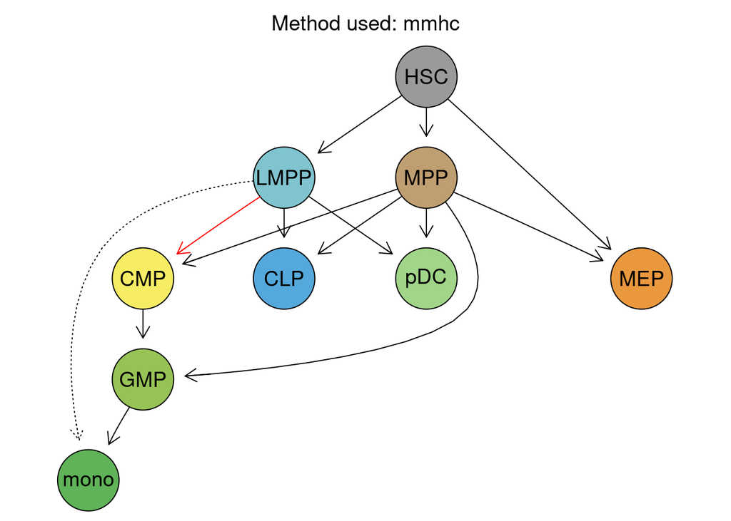

```r
tmp<-graphviz.plot(e,shape = 'circle',main=paste0('Method used: ','mmhc'),render = F)
nodeRenderInfo(tmp) <- draw_para;edgeRenderInfo(tmp) <- draw_para3;renderGraph(tmp)
```

### try different sampling ratio

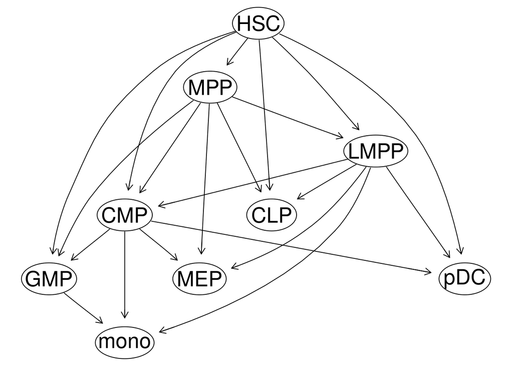

```r
a <- BNLearning(HHATAC_TF, frac = 0.7, N_smpl = 20, params = seq(0.01,0.02,0.001),
                whiteList = NULL, blackList = NULL, root = 'HSC',
                ugMethod = 'space', dagMethod = 'hc', ncores = 20,mode = 'single_cell')
tmp <- lapply(a,function(x){df2mat(combineDAGs(x,Emin = 1,Emax = 50))})
b = norm_mat(tmp[[1]][ctypes,ctypes]);for (i in 2:length(tmp)) {b = b + norm_mat(tmp[[i]][ctypes,ctypes])}
b = rmCycL(mat2df(b))
e <-  empty.graph(ctypes)
strc1 <- (b)[,1:2];strc1[,1]=as.character(strc1[,1]);strc1[,2]=as.character(strc1[,2])
arcs(e) <-  strc1
e=arc_modify(atac_data[names(HHATAC_TF_glist)[441:882],],e,2,3,1)
```

```r
e=arc_modify(atac_data[names(HHATAC_TF_glist)[1:442],],e,2,2,1)
```

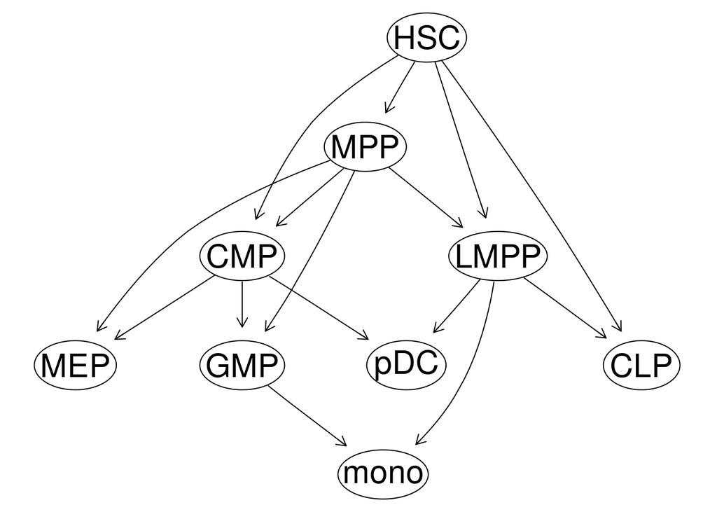

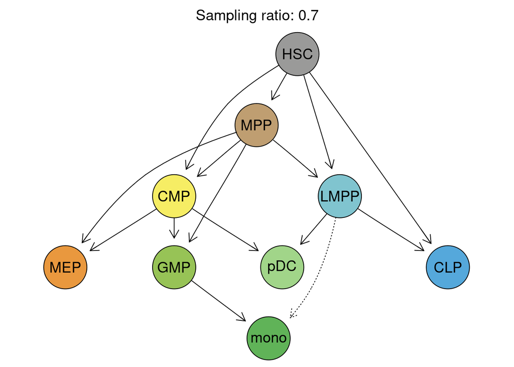

```r
tmp<-graphviz.plot(e,shape = 'circle',main=paste0('Sampling ratio: ','0.7'),render = F)
nodeRenderInfo(tmp) <- draw_para;edgeRenderInfo(tmp) <- draw_para3;renderGraph(tmp)
```

## Utilizing diffBN data

We first define necessary cell type sets

```r
ctypes.stem <- "HSC"
ctypes.early <- c("MPPa", "MPPb")
ctypes.myl <- c("sCMP", "GMP", "MEP", "MkP", "pCFU-E")
ctypes.lym <- c("CLP", "BLP", "DN1")
ctypes.all <- c(ctypes.stem, ctypes.early, ctypes.myl, ctypes.lym)
ctypes <- c(rep("early", length(ctypes.stem) + length(ctypes.early)), rep("myl",
    length(ctypes.myl)), rep("lym", length(ctypes.lym)))
```

`setEdges` is used for generating edge set. Use `diffScore` to get the score of selected genes and use function `dsRank` to obtain ranked gene list.

```r
s.diffScore <- setEdges(ctypes.all, ctypes.all, sep = "~")
ds.diffScore <- diffScore(diffBN, s.diffScore, abs = TRUE)
# Gene list ranked according to the diffScore
gl.diffScore <- dsRank(ds.diffScore)
head(gl.diffScore)
```

```
## [1] "ENSG00000008196-LINE2-TFAP2B-D-N1" "ENSG00000008196-LINE3-TFAP2B-D-N1"
## [3] "ENSG00000008196-LINE4-TFAP2B-D-N1" "ENSG00000008196-LINE5-TFAP2B-D-N1"
## [5] "ENSG00000008197-LINE6-TFAP2D-D"    "ENSG00000087510-LINE7-TFAP2C-D-N3"
```